# Nigeria Crop Consumption

#### Wheat consumption

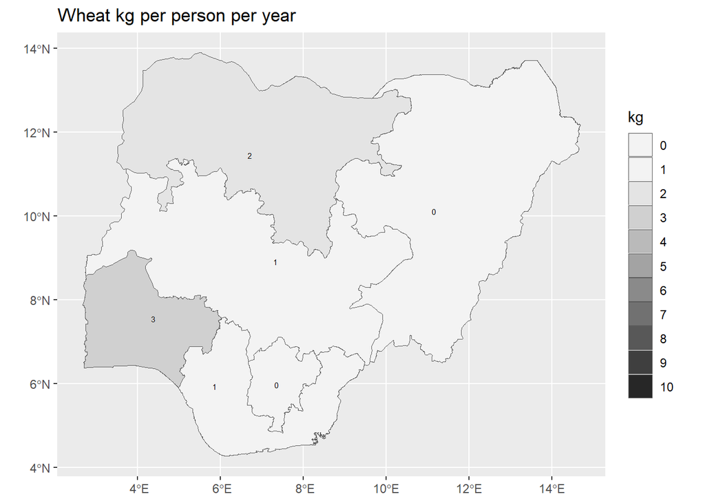

```r
ggplot(tidyterra::filter(vect_gpz_geo_GHS_crop, crop == "Wheat")) +
  geom_spatvector(aes(fill = crop_equivalent_kg_person_year)) +
  geom_spatvector_text(aes(label = round(crop_equivalent_kg_person_year)), size = 2) +
  scale_fill_stepsn(
    n.breaks = 10,
    limits = c(0, 10),
    colours = hcl.colors(palette = "Grays", 10, rev = T),
    guide = "legend",
    na.value = "pink",
    labels = scales::comma
  ) +
  labs(title = "Wheat kg per person per year", fill = "kg") +
  theme(
    plot.title = element_markdown(),
    legend.title = element_markdown(),
    axis.title = element_blank()
  )
```

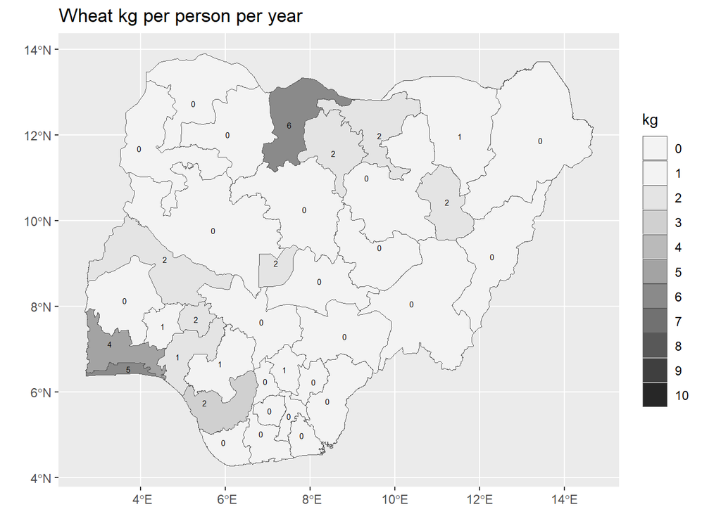

```r
ggplot(tidyterra::filter(vect_state_geo_GHS_crop, crop == "Wheat")) +
  geom_spatvector(aes(fill = crop_equivalent_kg_person_year)) +
  geom_spatvector_text(aes(label = round(crop_equivalent_kg_person_year)), size = 2) +
  scale_fill_stepsn(
    n.breaks = 10,
    limits = c(0, 10),
    colours = hcl.colors(palette = "Grays", 10, rev = T),
    guide = "legend",
    na.value = "pink",
    labels = scales::comma
  ) +
  labs(title = "Wheat kg per person per year", fill = "kg") +
  theme(
    plot.title = element_markdown(),
    legend.title = element_markdown(),
    axis.title = element_blank()
  )
```

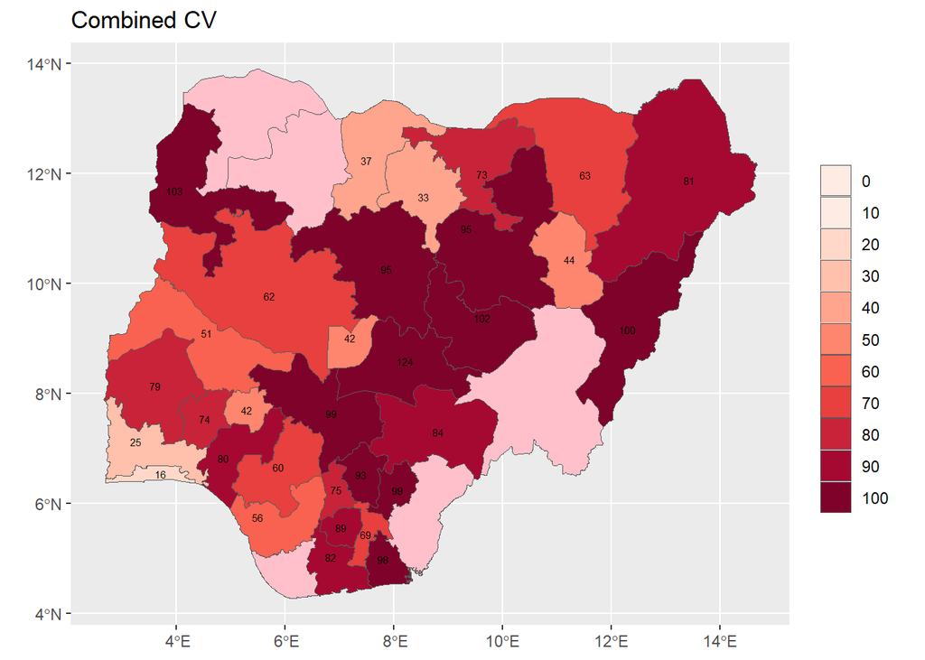

```r
ggplot(tidyterra::filter(vect_state_geo_GHS_crop, crop == "Wheat")) +
  geom_spatvector(aes(fill = crop_cv_combined)) +
  geom_spatvector_text(aes(label = round(crop_cv_combined)), size = 2) +
  scale_fill_stepsn(
    n.breaks = 10,
    limits = c(0, 100),
    colours = hcl.colors(palette = "Reds", 6, rev = T),
    guide = "legend",
    na.value = "pink",
    labels = scales::comma
  ) +
  labs(title = "Combined CV", fill = NA) +
  theme(
    plot.title = element_markdown(),
    legend.title = element_markdown(),
    axis.title = element_blank()
  )
```

#### Yam consumption

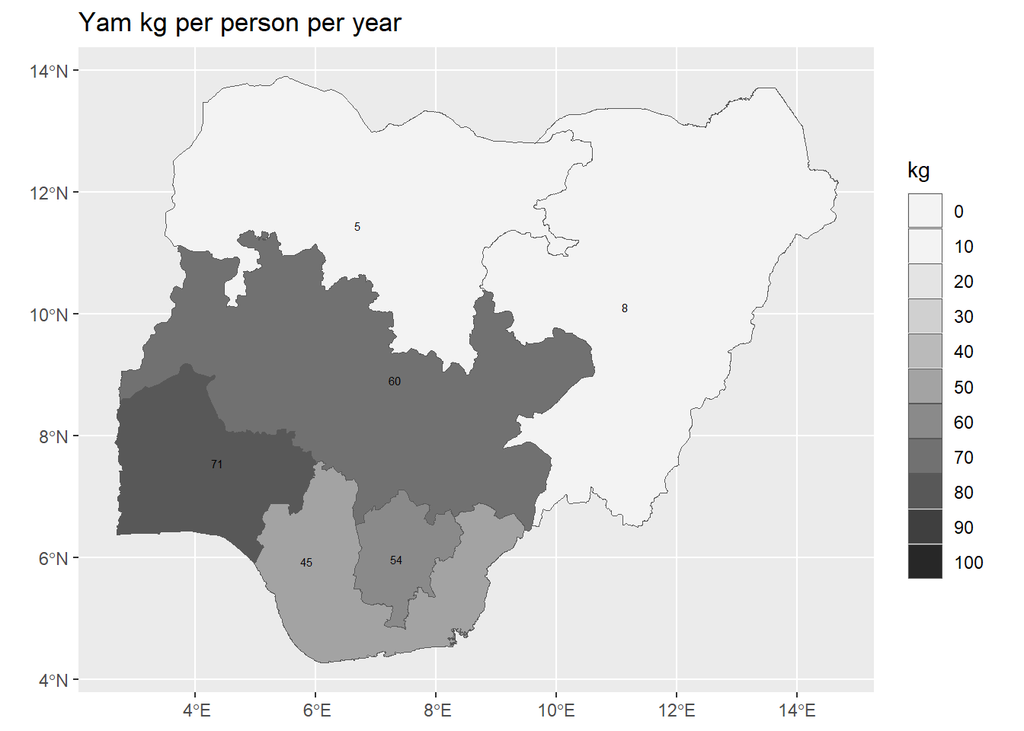

```r
ggplot(tidyterra::filter(vect_gpz_geo_GHS_crop, crop == "Yam")) +
  geom_spatvector(aes(fill = crop_equivalent_kg_person_year)) +
  geom_spatvector_text(aes(label = round(crop_equivalent_kg_person_year)), size = 2) +
  scale_fill_stepsn(
    n.breaks = 10,
    limits = c(0, 100),
    colours = hcl.colors(palette = "Grays", 10, rev = T),
    guide = "legend",
    na.value = "pink",
    labels = scales::comma
  ) +
  labs(title = "Yam kg per person per year", fill = "kg") +
  theme(
    plot.title = element_markdown(),
    legend.title = element_markdown(),
    axis.title = element_blank()
  )
```

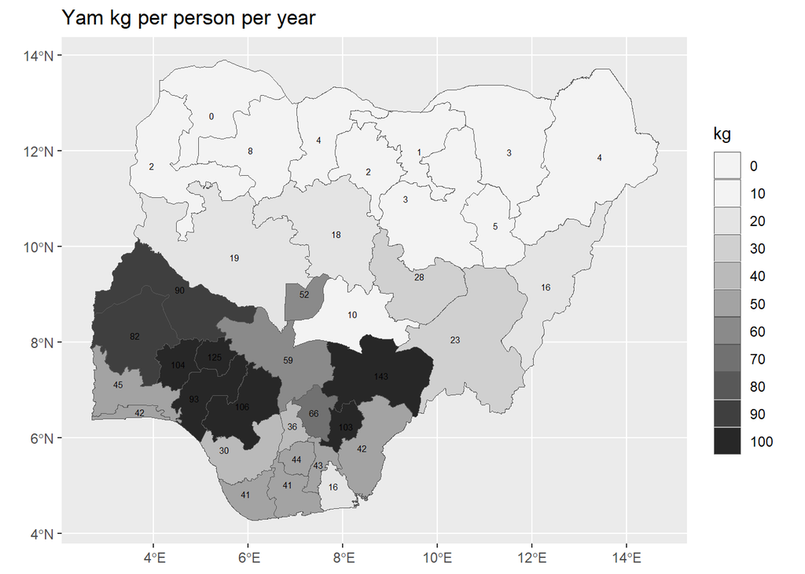

```r
ggplot(tidyterra::filter(vect_state_geo_GHS_crop, crop == "Yam")) +
  geom_spatvector(aes(fill = crop_equivalent_kg_person_year)) +
  geom_spatvector_text(aes(label = round(crop_equivalent_kg_person_year)), size = 2) +
  scale_fill_stepsn(
    n.breaks = 10,
    limits = c(0, 100),
    colours = hcl.colors(palette = "Grays", 10, rev = T),
    guide = "legend",
    na.value = "pink",
    labels = scales::comma
  ) +
  labs(title = "Yam kg per person per year", fill = "kg") +
  theme(
    plot.title = element_markdown(),
    legend.title = element_markdown(),
    axis.title = element_blank()
  )
```

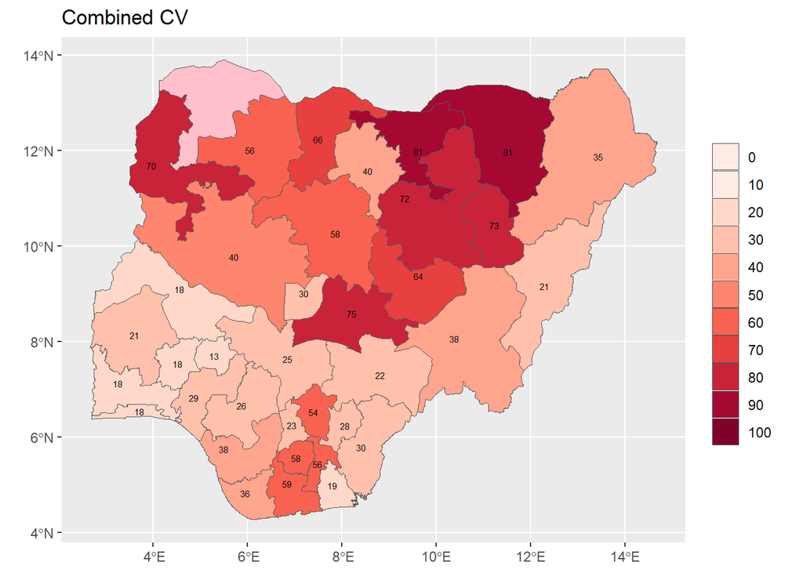

```r
ggplot(tidyterra::filter(vect_state_geo_GHS_crop, crop == "Yam")) +
  geom_spatvector(aes(fill = crop_cv_combined)) +
  geom_spatvector_text(aes(label = round(crop_cv_combined)), size = 2) +
  scale_fill_stepsn(
    n.breaks = 10,
    limits = c(0, 100),
    colours = hcl.colors(palette = "Reds", 6, rev = T),
    guide = "legend",
    na.value = "pink",
    labels = scales::comma
  ) +
  labs(title = "Combined CV", fill = NA) +
  theme(
    plot.title = element_markdown(),
    legend.title = element_markdown(),
    axis.title = element_blank()
  )
```

## Smoothed Crop Consumption

```r
# create queen neighbours
# Find Queen contiguity (default)
# queen_adj <- adjacent(vect_state_geo, type="queen", pairs=TRUE)

state_names <- vect_state_geo$adm1_ref_name
sf_polygons <- st_as_sf(vect_state_geo)|> st_make_valid()

# Build neighbour list (Queen contiguity)
nb_list <- poly2nb(sf_polygons, queen = TRUE)

#state_names

# Convert neighbour list to a spatial weights matrix
weights_list <- nb2listw(nb_list, style = "W",
  zero.policy = TRUE)

weights_matrix <- listw2mat(weights_list)

rownames(weights_matrix) <- state_names
colnames(weights_matrix) <- state_names
```

```r
df_GHS_pop_state_pp <- read.csv("tab_data/GHS food per capita outputs/GHS_wave5_food_consumption_state_planting.csv") |> select(state, zone, n_households,  n_psu, weighted_population, median_household_size, mean_household_size) |> distinct()

df_GHS_pop_state_pp <- df_GHS_pop_state_pp |>
  mutate(state = trimws(gsub("[^A-Za-z ]", "", state)))
df_GHS_pop_state_pp <- df_GHS_pop_state_pp |>
  mutate(zone = trimws(gsub("[^A-Za-z ]", "", zone)))

# change name to match states dataset
df_GHS_pop_state_pp['state'][df_GHS_pop_state_pp['state'] == "FCT"] <- "Federal Capital Territory"


df_GHS_pop_state_ph <- read.csv("tab_data/GHS food per capita outputs/GHS_wave5_food_consumption_state_harvest.csv") |> select(state, zone, n_households,   n_psu, weighted_population, median_household_size, mean_household_size) |> distinct()

df_GHS_pop_state_ph <- df_GHS_pop_state_ph |>
  mutate(state = trimws(gsub("[^A-Za-z ]", "", state)))
df_GHS_pop_state_ph <- df_GHS_pop_state_ph |>
  mutate(zone = trimws(gsub("[^A-Za-z ]", "", zone)))
df_GHS_pop_state_ph['state'][df_GHS_pop_state_ph['state'] == "FCT"] <- "Federal Capital Territory"

df_GHS_pop_state <- left_join(
  df_GHS_pop_state_pp,
  df_GHS_pop_state_ph,
  by = "state"
) |>
  rowwise() |>
  mutate(
    zone = zone.x,
    n_households = mean(c(n_households.x, n_households.y), na.rm = T),
    n_psu = mean(c(n_psu.x, n_psu.y), na.rm = T),
    weighted_population = mean(
      c(weighted_population.x, weighted_population.y),
      na.rm = T
    ),
    median_household_size = mean(
      c(median_household_size.x, median_household_size.y),
      na.rm = T
    ),
    mean_household_size = mean(
      c(mean_household_size.x, mean_household_size.y),
      na.rm = T
    )
  ) |>
  rename(
    n_households_pp = n_households.x,
    n_households_ph = n_households.y,
    n_psu_pp = n_psu.x,
    n_psu_ph = n_psu.y,
    mean_household_size_pp = mean_household_size.x,
    mean_household_size_ph = mean_household_size.y,
    median_household_size_pp = median_household_size.x,
    median_household_size_ph = median_household_size.y,
    weighted_population_pp = weighted_population.x,
    weighted_population_ph = weighted_population.y
  ) |>
  select(
    state,
    zone,
    weighted_population_pp,
    weighted_population_ph,
    weighted_population,
    n_households_pp,
    n_households_ph,
    n_households,
    n_psu_pp,
    n_psu_ph,
    n_psu,
    mean_household_size_pp,
    mean_household_size_ph,
    mean_household_size,
    median_household_size_pp,
    median_household_size_ph,
    median_household_size
  )


# get the zonal population

df_GHS_pop_zone <- df_GHS_pop_state |>
  group_by(
    zone
  ) |>
  summarise(
    weighted_population_zone = sum(weighted_population, na.rm = TRUE),
    .groups = "drop"
  )

# add zonal population to the state

df_GHS_pop_state <- df_GHS_pop_state |>
  left_join(df_GHS_pop_zone, by = "zone")
```

```r
df_GHS_pop_crop_state <- df_GHS_crop_state |>
  left_join(df_GHS_pop_state, by = c("state")) |>
    left_join(df_GHS_crop_zone, by = c("zone", "crop")) |>
rename(
    crop_equivalent_low_state = crop_equivalent_low.x,
    crop_equivalent_low_zone = crop_equivalent_low.y,
    crop_equivalent_kg_person_year_state = crop_equivalent_kg_person_year.x,
    crop_equivalent_kg_person_year_zone = crop_equivalent_kg_person_year.y,
    crop_equivalent_high_state = crop_equivalent_high.x,
    crop_equivalent_high_zone = crop_equivalent_high.y)
```

### Spatial lag to smooth state estimates

```r
# ============================================================
# 1. INPUTS
# ============================================================

# Expected columns in df_GHS_pop_crop_state  :
#
# crop
# state
# zone
# crop_equivalent_kg_person_year_state       = direct state kg/person/year
# crop_equivalent_kg_person_year_zone        = survey-supported zone kg/person/year
# weighted_population     = weighted population of state
# weighted_population_zone      = weighted population of zone
#
# weights_matrix = row-standardised queen spatial weights matrix
#
# IMPORTANT:
# The rows/columns of weights_matrix must correspond to the STATE names
# used in df_GHS_pop_crop_state.
# ============================================================
```

```r
# ============================================================
# 2. CHECK THE POPULATION / ZONE INFORMATION
# ============================================================

zone_check <- df_GHS_pop_crop_state |>
  group_by(crop, zone) |>
  summarise(
    crop_equivalent_kg_person_year_zone = first(crop_equivalent_kg_person_year_zone),
    weighted_population_zone = first(weighted_population_zone),

    sum_weighted_population =
      sum(weighted_population, na.rm = TRUE),

    n_states = n(),

    .groups = "drop"
  ) |>
  mutate(
    population_difference =
      sum_weighted_population - weighted_population_zone
  )

zone_check |>
  DT::datatable(
    rownames = F,
    colnames=c("Crop", "Zone", "Zone crop consumption estimate" ,"weighted population per zone", "sum_weighted_population ", "# States ", "Population Difference "),
    caption = "Check the Population per zone",
    selection = list(mode = "none"),
    editable = FALSE,
    options = list(
      digits = 0,
      scrollX = TRUE,
      scrollCollapse = TRUE,
      # autoWidth = TRUE,
      fixedColumns = list(leftColumns = 2),
      lengthMenu = c(15, 40),
      pageLength = 15
    ))
```

Table 19: Zone check

| Crop | Zone | Zone crop consumption estimate | weighted population per zone | sum_weighted_population | # States | Population Difference |
| --- | --- | --- | --- | --- | --- | --- |
| Cassava | North Central | 89.23083919541823 | 33271143.54525127 | 33271143.54525127 | 7 | 0 |
| Cassava | North East | 65.54746658433292 | 32648367.78098391 | 32648367.78098391 | 6 | 0 |
| Cassava | North West | 60.25888427734957 | 63064815.14721394 | 63064815.14721394 | 7 | 0 |
| Cassava | South East | 154.7493714964525 | 24469631.60948114 | 24469631.60948114 | 5 | 0 |
| Cassava | South South | 233.8460665047694 | 31222076.03572947 | 31222076.03572947 | 6 | 0 |
| Cassava | South West | 106.1408605129903 | 42686077.57844689 | 42686077.57844689 | 6 | 0 |
| Cocoyam | North Central | 0.4077475554690789 | 33271143.54525127 | 33271143.54525127 | 7 | 0 |
| Cocoyam | North East | 0.1042285673410652 | 32648367.78098391 | 32648367.78098391 | 6 | 0 |
| Cocoyam | North West | 0.2476040690610698 | 63064815.14721394 | 63064815.14721394 | 7 | 0 |
| Cocoyam | South East | 5.546484673351984 | 24469631.60948114 | 24469631.60948114 | 5 | 0 |

[output cut: 74 more lines]

```r
# ============================================================
# 3. CALCULATE THE DIRECT STATE / ZONE RATIO
# ============================================================

df_GHS_pop_crop_state <- df_GHS_pop_crop_state |>
  mutate(
    state_zone_ratio =
      crop_equivalent_kg_person_year_state / crop_equivalent_kg_person_year_zone
  )
```

```r
# ============================================================
# 4. SPATIAL LAG OF THE STATE / ZONE RATIO
# ============================================================

# Convert weights_matrix to a matrix if necessary.
#
# If weights_matrix is already a matrix:
weights_matrix_mat <- as.matrix(weights_matrix)

# Check dimensions
stopifnot(
  nrow(weights_matrix_mat) == ncol(weights_matrix_mat)
)

# ------------------------------------------------------------
# IMPORTANT:
# We need the states in df_GHS_pop_crop_state to be in exactly the same order
# as the rows/columns of weights_matrix.
# ------------------------------------------------------------

state_order <- rownames(weights_matrix_mat)

if (is.null(state_order)) {
  stop(
    "weights_matrix must have state names as row names."
  )
}


# Check that every state in df_GHS_pop_crop_state occurs in weights_matrix
missing_states <- setdiff(
  unique(df_GHS_pop_crop_state$state),
  state_order
)

if (length(missing_states) > 0) {

  stop(
    "These states are missing from weights_matrix: ",
    paste(missing_states, collapse = ", ")
  )
}


# ------------------------------------------------------------
# Function to calculate spatially lagged ratios
# ------------------------------------------------------------

spatial_lag_ratio <- function(
    state_names,
    values,
    weights_matrix_mat
) {

  # Put values into the same order as weights_matrix
  x <- setNames(
    values,
    state_names
  )

  x_ordered <- x[
    rownames(weights_matrix_mat)
  ]

  # Spatial lag
  lagged <- as.numeric(
    weights_matrix_mat %*% x_ordered
  )

  names(lagged) <-
    rownames(weights_matrix_mat)

  # Return in original state order
  lagged[state_names]
}


# ------------------------------------------------------------
# Apply to each crop
#
# We calculate the spatial lag separately for each crop.
# ------------------------------------------------------------

df_GHS_pop_crop_state <- df_GHS_pop_crop_state |>
  group_by(crop) |>
  mutate(
    spatial_lag_ratio =
      spatial_lag_ratio(
        state,
        state_zone_ratio,
        weights_matrix_mat
      )
  ) |>
  ungroup()
```

```r
# ============================================================
# 5. CREATE THE UNBENCHMARKED SPATIAL ESTIMATE
# ============================================================

df_GHS_pop_crop_state <- df_GHS_pop_crop_state |>
  mutate(
    smoothed_ratio =
      spatial_lag_ratio,

    smoothed_crop_equivalent_kg_person_year_state =
      #smoothed_ratio * crop_equivalent_kg_person_year_zone
      smoothed_ratio * crop_equivalent_kg_person_year_state
  )
```

```r
# ============================================================
# 6. CALCULATE THE UNBENCHMARKED STATE TOTAL
# ============================================================

df_GHS_pop_crop_state <- df_GHS_pop_crop_state |>
  mutate(
    smoothed_state_total =
      smoothed_crop_equivalent_kg_person_year_state *
      weighted_population
  )
```

```r
# ============================================================
# 7. CALCULATE THE ZONAL BENCHMARK
# ============================================================

# The benchmark is:
#
# zone consumption =
# zone per-capita consumption × zone population
#
# We compare this with the population-weighted total of
# the spatially smoothed state estimates.

benchmark <- df_GHS_pop_crop_state |>
  group_by(crop, zone) |>
  summarise(

    crop_equivalent_kg_person_year_zone =
      first(crop_equivalent_kg_person_year_zone),

    weighted_population_zone =
      first(weighted_population_zone),

    zone_total =
      crop_equivalent_kg_person_year_zone *
      weighted_population_zone,

    smoothed_state_total =
      sum(
        smoothed_state_total,
        na.rm = TRUE
      ),

    .groups = "drop"
  ) |>
  mutate(

    benchmark_factor =
      zone_total /
      smoothed_state_total

  )
```

```r
# ============================================================
# 8. APPLY THE BENCHMARK
# ============================================================

df_GHS_pop_crop_state <- df_GHS_pop_crop_state |>

  left_join(
    benchmark |>
      select(
        crop,
        zone,
        benchmark_factor
      ),
    by = c(
      "crop",
      "zone"
    )
  ) |>

  mutate(

    benchmarked_crop_equivalent_kg_person_year_state =
      smoothed_crop_equivalent_kg_person_year_state *
      benchmark_factor,

    benchmarked_state_total =
      benchmarked_crop_equivalent_kg_person_year_state *
      weighted_population

  )
```

```r
# ============================================================
# 9. FINAL CHECK
# ============================================================

benchmark_check <- df_GHS_pop_crop_state |>

  group_by(
    crop,
    zone
  ) |>

  summarise(

    crop_equivalent_kg_person_year_zone =
      first(crop_equivalent_kg_person_year_zone),

    weighted_population_zone =
      first(weighted_population_zone),

    zone_total =
      crop_equivalent_kg_person_year_zone *
      weighted_population_zone,

    benchmarked_state_total =
      sum(
        benchmarked_state_total,
        na.rm = TRUE
      ),

    difference =
      benchmarked_state_total -
      zone_total,

    percentage_difference =
      100 *
      difference /
      zone_total,

    .groups = "drop"

  )

benchmark_check |>
  DT::datatable(
    rownames = F,
    colnames=c("Crop", "Zone", "Zone crop consumption estimate" ,"weighted population per zone", "Total consumption per zone", "benchmarked_state_total  ", "Consumption Difference ", "% Difference "),
    caption = "Check the Benchmark",
    selection = list(mode = "none"),
    editable = FALSE,
    options = list(
      digits = 0,
      scrollX = TRUE,
      scrollCollapse = TRUE,
      # autoWidth = TRUE,
      fixedColumns = list(leftColumns = 2),
      lengthMenu = c(15, 40),
      pageLength = 15
    ))
```

Table 20: Benchmark check

| Crop | Zone | Zone crop consumption estimate | weighted population per zone | Total consumption per zone | benchmarked_state_total | Consumption Difference | % Difference |
| --- | --- | --- | --- | --- | --- | --- | --- |
| Cassava | North Central | 89.23083919541823 | 33271143.54525127 | 2968812059.533993 | 2968812059.533992 | -4.76837158203125e-07 | -1.606154746885436e-14 |
| Cassava | North East | 65.54746658433292 | 32648367.78098391 | 2140017796.157055 | 2140017796.157055 | 0 | 0 |
| Cassava | North West | 60.25888427734957 | 63064815.14721394 | 3800215397.928407 | 3800215397.928407 | 0 | 0 |
| Cassava | South East | 154.7493714964525 | 24469631.60948114 | 3786660112.316934 | 3786660112.316934 | 0 | 0 |
| Cassava | South South | 233.8460665047694 | 31222076.03572947 | 7301159669.068161 | 7301159669.068161 | 0 | 0 |
| Cassava | South West | 106.1408605129903 | 42686077.57844689 | 4530737006.100613 | 4530737006.100613 | 0 | 0 |
| Cocoyam | North Central | 0.4077475554690789 | 33271143.54525127 | 13566227.44823703 | 13566227.44823703 | 0 | 0 |
| Cocoyam | North East | 0.1042285673410652 | 32648367.78098391 | 3402892.599836144 | 3402892.599836144 | 4.656612873077393e-10 | 1.368427811474749e-14 |
| Cocoyam | North West | 0.2476040690610698 | 63064815.14721394 | 15615104.84503436 | 15615104.84503436 | 0 | 0 |
| Cocoyam | South East | 5.546484673351984 | 24469631.60948114 | 135720436.6845564 | 135720436.6845564 | 0 | 0 |

[output cut: 74 more lines]

```r
# ============================================================
# 10. SAVE OUTPUTS
# ============================================================


write_csv(
  df_GHS_pop_crop_state,
  "tab_data/GHS food per capita outputs/crop_state_results_benchmarked_smoothed.csv"
)
```

### Join back to States dataset

```r
vect_state_geo_GHS_crop <- dplyr::left_join(vect_state_geo, df_GHS_pop_crop_state, by = c("adm1_ref_name" = "state"))
vect_state_geo_GHS_crop |>
  as.data.frame() |>
  select(
    zone,
    adm1_ref_name,
    crop,
    crop_equivalent_kg_person_year_state,
    crop_equivalent_kg_person_year_zone,
    benchmarked_crop_equivalent_kg_person_year_state
  ) |>
  mutate(
    crop_equivalent_kg_person_year_state = prettyunits::pretty_round(
      crop_equivalent_kg_person_year_state,
      digits = 0
    ),
    crop_equivalent_kg_person_year_zone = prettyunits::pretty_round(crop_equivalent_kg_person_year_zone, digits = 0),
    benchmarked_crop_equivalent_kg_person_year_state = prettyunits::pretty_round(
      benchmarked_crop_equivalent_kg_person_year_state,
      digits = 0
    )
  ) |>
  DT::datatable(
    rownames = F,
    colnames = c(
      "Zone",
      "State",
      "Crop",
      "State - Annual Per Capita consumption (kg)",
      "Zone - Annual Per Capita consumption (kg)",
      "State Smoothed Benchmarked - Annual Per Capita consumption (kg)"
    ),
    caption = "GHS crop consumption zone summary",
    filter = "bottom",
    selection = list(mode = "none"),
    editable = FALSE,
    options = list(
      digits = 0,
      scrollX = TRUE,
      scrollCollapse = TRUE,
      autoWidth = TRUE,
      fixedColumns = list(leftColumns = 2),
      lengthMenu = c(15, 40),
      pageLength = 15
    )
  )
```

| Zone | State | Crop | State - Annual Per Capita consumption (kg) | Zone - Annual Per Capita consumption (kg) | State Smoothed Benchmarked - Annual Per Capita consumption (kg) |
| --- | --- | --- | --- | --- | --- |
| South East | Abia | Cassava | 129 | 155 | 135 |
| South East | Abia | Cocoyam | 0 | 6 | 1 |
| South East | Abia | Cowpea | 13 | 11 | 12 |
| South East | Abia | Groundnut | 2 | 2 | 2 |
| South East | Abia | Maize | 10 | 11 | 10 |
| South East | Abia | Millet | 0 | 0 | 0 |
| South East | Abia | Plantain | 9 | 8 | 10 |
| South East | Abia | Potato | 1 | 0 | 1 |
| South East | Abia | Rice | 26 | 27 | 26 |
| South East | Abia | Sorghum | 0 | 0 | 0 |

[output cut: 508 more lines]

### Plot the benchmarked and smoothed consumption results

#### Cassava consumption

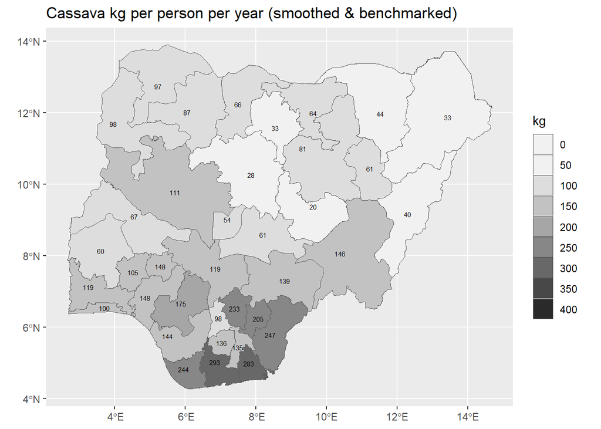

```r
ggplot(tidyterra::filter(vect_state_geo_GHS_crop, crop == "Cassava")) +
  geom_spatvector(aes(fill = benchmarked_crop_equivalent_kg_person_year_state)) +
  geom_spatvector_text(aes(label = round(benchmarked_crop_equivalent_kg_person_year_state)), size = 2) +
  scale_fill_stepsn(
    n.breaks = 10,
    limits = c(0, 400),
    colours = hcl.colors(palette = "Grays", 10, rev = T),
    guide = "legend",
    na.value = "pink",
    labels = scales::comma
  ) +
  labs(title = "Cassava kg per person per year (smoothed & benchmarked)", fill = "kg") +
  theme(
    plot.title = element_markdown(),
    legend.title = element_markdown(),
    axis.title = element_blank()
  )
```

#### Cocoyam consumption

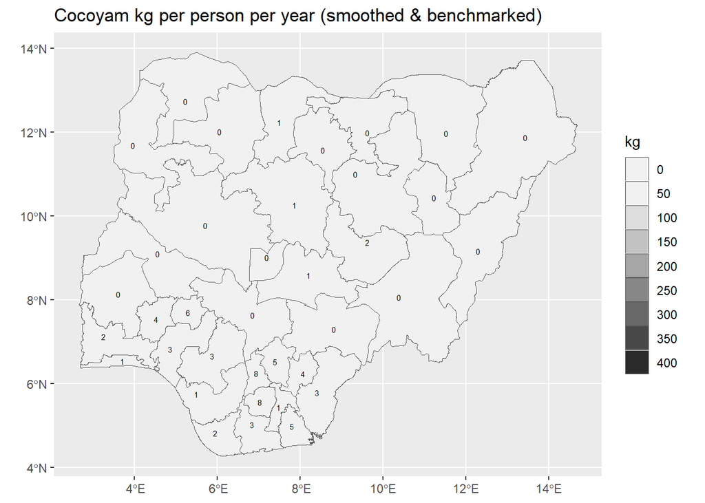

```r
ggplot(tidyterra::filter(vect_state_geo_GHS_crop, crop == "Cocoyam")) +
  geom_spatvector(aes(fill = benchmarked_crop_equivalent_kg_person_year_state)) +
  geom_spatvector_text(aes(label = round(benchmarked_crop_equivalent_kg_person_year_state)), size = 2) +
  scale_fill_stepsn(
    n.breaks = 10,
    limits = c(0, 400),
    colours = hcl.colors(palette = "Grays", 10, rev = T),
    guide = "legend",
    na.value = "pink",
    labels = scales::comma
  ) +
  labs(title = "Cocoyam kg per person per year (smoothed & benchmarked)", fill = "kg") +
  theme(
    plot.title = element_markdown(),
    legend.title = element_markdown(),
    axis.title = element_blank()
  )
```

#### Cowpea consumption

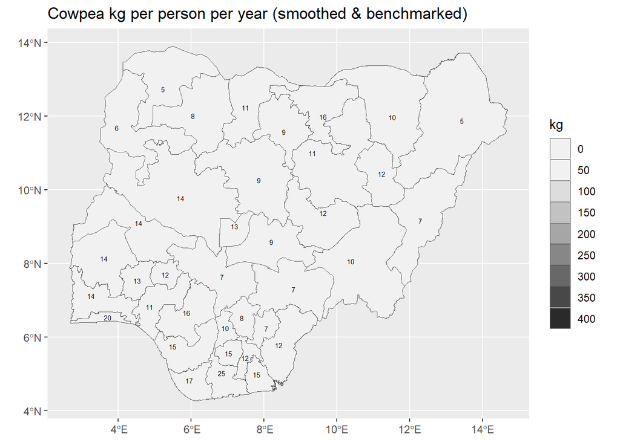

```r
ggplot(tidyterra::filter(vect_state_geo_GHS_crop, crop == "Cowpea")) +
  geom_spatvector(aes(fill = benchmarked_crop_equivalent_kg_person_year_state)) +
  geom_spatvector_text(aes(label = round(benchmarked_crop_equivalent_kg_person_year_state)), size = 2) +
  scale_fill_stepsn(
    n.breaks = 10,
    limits = c(0, 400),
    colours = hcl.colors(palette = "Grays", 10, rev = T),
    guide = "legend",
    na.value = "pink",
    labels = scales::comma
  ) +
  labs(title = "Cowpea kg per person per year (smoothed & benchmarked)", fill = "kg") +
  theme(
    plot.title = element_markdown(),
    legend.title = element_markdown(),
    axis.title = element_blank()
  )
```

#### Maize consumption

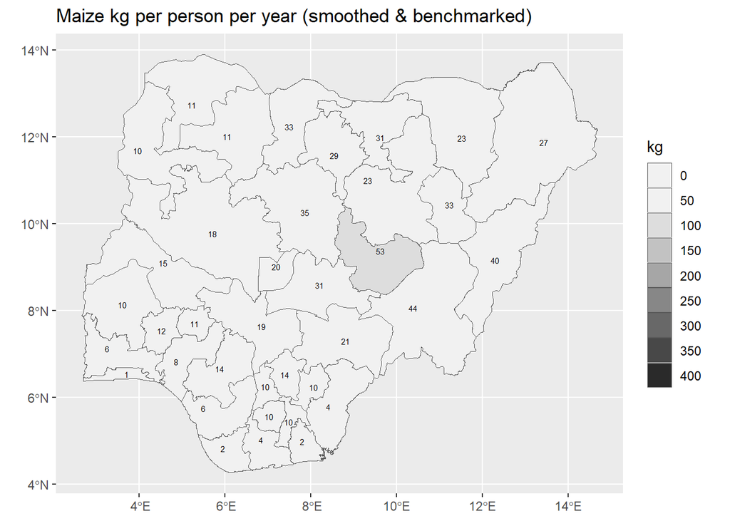

```r
ggplot(tidyterra::filter(vect_state_geo_GHS_crop, crop == "Maize")) +
  geom_spatvector(aes(fill = benchmarked_crop_equivalent_kg_person_year_state)) +
  geom_spatvector_text(aes(label = round(benchmarked_crop_equivalent_kg_person_year_state)), size = 2) +
  scale_fill_stepsn(
    n.breaks = 10,
    limits = c(0, 400),
    colours = hcl.colors(palette = "Grays", 10, rev = T),
    guide = "legend",
    na.value = "pink",
    labels = scales::comma
  ) +
  labs(title = "Maize kg per person per year (smoothed & benchmarked)", fill = "kg") +
  theme(
    plot.title = element_markdown(),
    legend.title = element_markdown(),
    axis.title = element_blank()
  )
```

#### Millet consumption

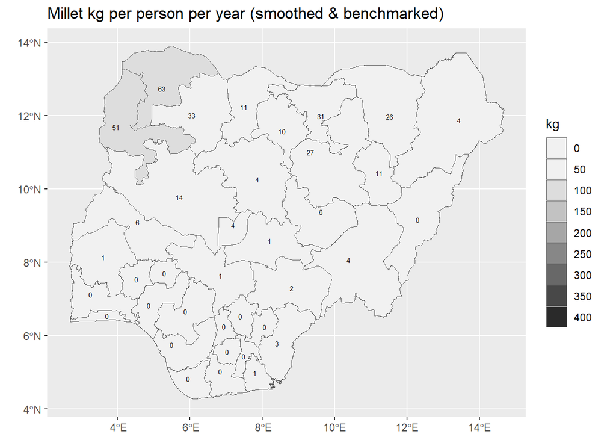

```r
ggplot(tidyterra::filter(vect_state_geo_GHS_crop, crop == "Millet")) +
  geom_spatvector(aes(fill = benchmarked_crop_equivalent_kg_person_year_state)) +
  geom_spatvector_text(aes(label = round(benchmarked_crop_equivalent_kg_person_year_state)), size = 2) +
  scale_fill_stepsn(
    n.breaks = 10,
    limits = c(0, 400),
    colours = hcl.colors(palette = "Grays", 10, rev = T),
    guide = "legend",
    na.value = "pink",
    labels = scales::comma
  ) +
  labs(title = "Millet kg per person per year (smoothed & benchmarked)", fill = "kg") +
  theme(
    plot.title = element_markdown(),
    legend.title = element_markdown(),
    axis.title = element_blank()
  )
```

#### Potato consumption

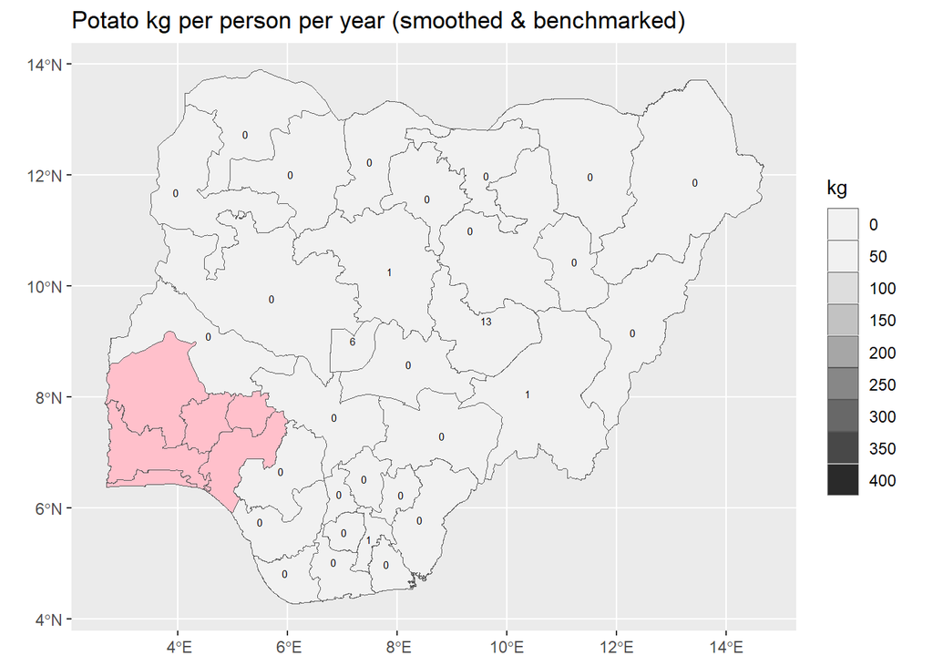

```r
ggplot(tidyterra::filter(vect_state_geo_GHS_crop, crop == "Potato")) +
  geom_spatvector(aes(fill = benchmarked_crop_equivalent_kg_person_year_state)) +
  geom_spatvector_text(aes(label = round(benchmarked_crop_equivalent_kg_person_year_state)), size = 2) +
  scale_fill_stepsn(
    n.breaks = 10,
    limits = c(0, 400),
    colours = hcl.colors(palette = "Grays", 10, rev = T),
    guide = "legend",
    na.value = "pink",
    labels = scales::comma
  ) +
  labs(title = "Potato kg per person per year (smoothed & benchmarked)", fill = "kg") +
  theme(
    plot.title = element_markdown(),
    legend.title = element_markdown(),
    axis.title = element_blank()
  )
```

#### Plantain consumption

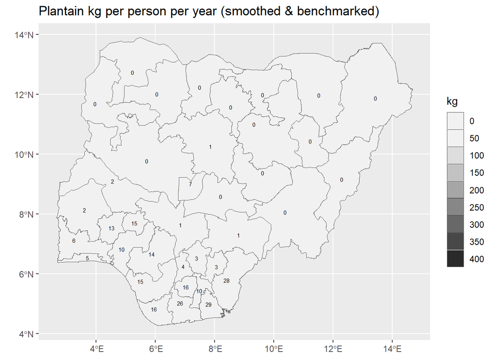

```r
ggplot(tidyterra::filter(vect_state_geo_GHS_crop, crop == "Plantain")) +
  geom_spatvector(aes(fill = benchmarked_crop_equivalent_kg_person_year_state)) +
  geom_spatvector_text(aes(label = round(benchmarked_crop_equivalent_kg_person_year_state)), size = 2) +
  scale_fill_stepsn(
    n.breaks = 10,
    limits = c(0, 400),
    colours = hcl.colors(palette = "Grays", 10, rev = T),
    guide = "legend",
    na.value = "pink",
    labels = scales::comma
  ) +
  labs(title = "Plantain kg per person per year (smoothed & benchmarked)", fill = "kg") +
  theme(
    plot.title = element_markdown(),
    legend.title = element_markdown(),
    axis.title = element_blank()
  )
```

#### Rice consumption

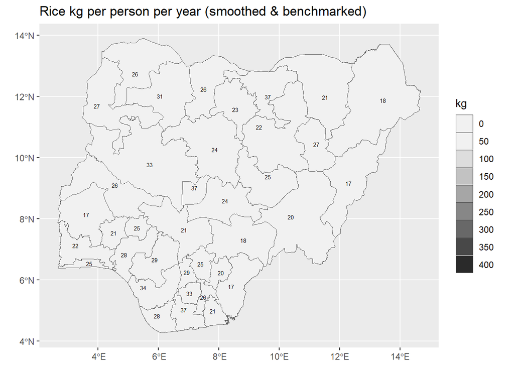

```r
ggplot(tidyterra::filter(vect_state_geo_GHS_crop, crop == "Rice")) +
  geom_spatvector(aes(fill = benchmarked_crop_equivalent_kg_person_year_state)) +
  geom_spatvector_text(aes(label = round(benchmarked_crop_equivalent_kg_person_year_state)), size = 2) +
  scale_fill_stepsn(
    n.breaks = 10,
    limits = c(0, 400),
    colours = hcl.colors(palette = "Grays", 10, rev = T),
    guide = "legend",
    na.value = "pink",
    labels = scales::comma
  ) +
  labs(title = "Rice kg per person per year (smoothed & benchmarked)", fill = "kg") +
  theme(
    plot.title = element_markdown(),
    legend.title = element_markdown(),
    axis.title = element_blank()
  )
```

#### Sorghum consumption

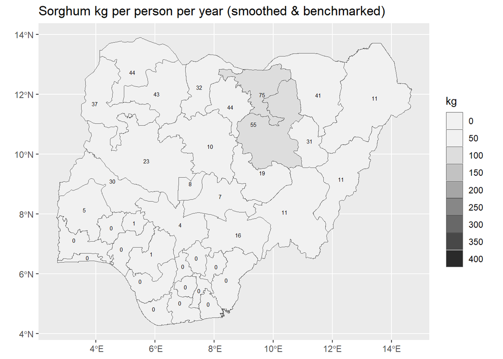

```r
ggplot(tidyterra::filter(vect_state_geo_GHS_crop, crop == "Sorghum")) +
  geom_spatvector(aes(fill = benchmarked_crop_equivalent_kg_person_year_state)) +
  geom_spatvector_text(aes(label = round(benchmarked_crop_equivalent_kg_person_year_state)), size = 2) +
  scale_fill_stepsn(
    n.breaks = 10,
    limits = c(0, 400),
    colours = hcl.colors(palette = "Grays", 10, rev = T),
    guide = "legend",
    na.value = "pink",
    labels = scales::comma
  ) +
  labs(title = "Sorghum kg per person per year (smoothed & benchmarked)", fill = "kg") +
  theme(
    plot.title = element_markdown(),
    legend.title = element_markdown(),
    axis.title = element_blank()
  )
```

#### Sweet Potato consumption

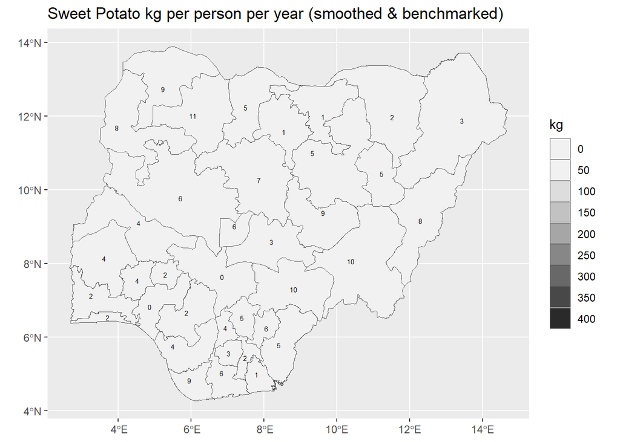

```r
ggplot(tidyterra::filter(vect_state_geo_GHS_crop, crop == "Sweet potato")) +
  geom_spatvector(aes(fill = benchmarked_crop_equivalent_kg_person_year_state)) +
  geom_spatvector_text(aes(label = round(benchmarked_crop_equivalent_kg_person_year_state)), size = 2) +
  scale_fill_stepsn(
    n.breaks = 10,
    limits = c(0, 400),
    colours = hcl.colors(palette = "Grays", 10, rev = T),
    guide = "legend",
    na.value = "pink",
    labels = scales::comma
  ) +
  labs(title = "Sweet Potato kg per person per year (smoothed & benchmarked)", fill = "kg") +
  theme(
    plot.title = element_markdown(),
    legend.title = element_markdown(),
    axis.title = element_blank()
  )
```

#### Wheat consumption

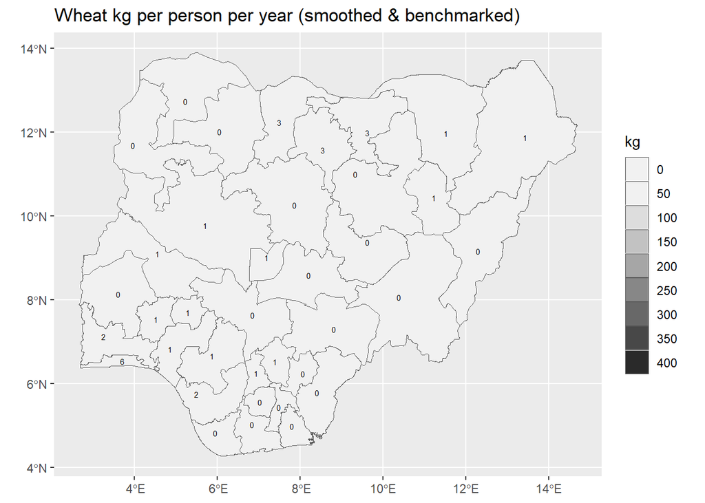

```r
ggplot(tidyterra::filter(vect_state_geo_GHS_crop, crop == "Wheat")) +
  geom_spatvector(aes(fill = benchmarked_crop_equivalent_kg_person_year_state)) +
  geom_spatvector_text(aes(label = round(benchmarked_crop_equivalent_kg_person_year_state)), size = 2) +
  scale_fill_stepsn(
    n.breaks = 10,
    limits = c(0, 400),
    colours = hcl.colors(palette = "Grays", 10, rev = T),
    guide = "legend",
    na.value = "pink",
    labels = scales::comma
  ) +
  labs(title = "Wheat kg per person per year (smoothed & benchmarked)", fill = "kg") +
  theme(
    plot.title = element_markdown(),
    legend.title = element_markdown(),
    axis.title = element_blank()
  )
```

#### Yam consumption

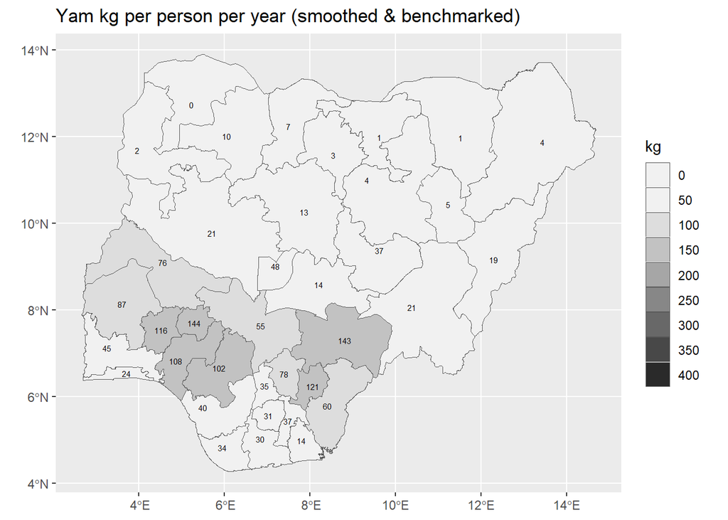

```r
ggplot(tidyterra::filter(vect_state_geo_GHS_crop, crop == "Yam")) +
  geom_spatvector(aes(fill = benchmarked_crop_equivalent_kg_person_year_state)) +
  geom_spatvector_text(aes(label = round(benchmarked_crop_equivalent_kg_person_year_state)), size = 2) +
  scale_fill_stepsn(
    n.breaks = 10,
    limits = c(0, 400),
    colours = hcl.colors(palette = "Grays", 10, rev = T),
    guide = "legend",
    na.value = "pink",
    labels = scales::comma
  ) +
  labs(title = "Yam kg per person per year (smoothed & benchmarked)", fill = "kg") +
  theme(
    plot.title = element_markdown(),
    legend.title = element_markdown(),
    axis.title = element_blank()
  )
```

# Appendix 1: Potential extra checks

**NoteNumber of days of consumption**

Section 5C – Aggregate Food Consumption file (`sect5c_harvestw5.dta`) represents an additional opportunity to check the validity of our results:

It has 56,580 observations and records the number of days the household consumed each food-group item during the previous seven days.

We did not use that for the kg calculation, but it was potentially useful as a quality check.

For example, if our calculation says a household consumed 50 kg of maize flour in seven days, we can check whether that household reported consuming maize flour on some/all of the seven days. It could help identify implausible conversion-factor results.

**CautionCheck the results**

Before we start converting food products into crops, we need to run the script and look specifically at state_sample and a few major products such as maize, cassava, rice and yam.

There is then a very useful diagnostic we can do: compare the state-level estimates aggregated back to Nigeria against the corresponding national/zone estimates. That will tell us whether the weighting and state-domain calculations are behaving as expected before we build the crop-equivalent calculations on top of them.

**NoteSensitivity Analysis**

We did not use the confidence intervals, coefficient of variation, or the upper and lower food to crop conversion factors in our analysis.

These could potentially be combined to show a range of results which could be incoporated in the sub national BPI for Nigeria.

## References

Asare-Marfo, Dorene, Ekin Birol, Carolina Gonzalez, et al. 2013. *Prioritizing Countries for Biofortifcation Interventions Using Country-Level Data*. Vol. 11. HarvestPlus.

Herrington, C., J. Funes, K. Lividini, et al. 2018. “Subnational Prioritization for Biofortification Interventions in Nigeria.” *30th International Conference of Agricultural Economists* (Vancouver, British Columbia, Canada), July. https://doi.org/10.22004/AG.ECON.277092.